# R Notebook

This document demonstrates the application of Non-negative Matrix Factorization (NMF) to RNA-seq count data for clustering ovarian cancer cell lines. The goal is to identify distinct gene expression patterns and associate them with actionable targets.

## Step 1: Data Preprocessing

Before running NMF, the RNA-seq data must be filtered for low-expression genes, normalized, and converted to a matrix suitable for decomposition.

```r
library(ggplot2)
library(pheatmap)
library(cluster)
library(Rtsne)
library(umap)
library(NbClust)
library(clusterProfiler)
library(org.Hs.eg.db)
library(randomForest)
library(ggplot2)
library(tidyr)
library(dplyr)
library(reshape2)
library(NMF)
set.seed(123)
```

```r
# 1. Data Preprocessing
counts <- read.csv("~/Github_Repos/MRCK_inhibition_BDP9066_ovarian_cancer/data/GSE94304-expression.txt", sep = '\t', row.names = 1)
metadata <- read.csv("~/Github_Repos/MRCK_inhibition_BDP9066_ovarian_cancer/data/GSE94304-metadata.txt", sep = '\t')

# Clean sample titles in metadata
metadata$Sample.Title <- gsub(pattern = "-", replacement = "_", metadata$Sample.Title)
metadata$Sample.Title <- gsub(pattern = "/", replacement = "_", metadata$Sample.Title)

# Update column names in counts to match metadata
colnames(counts) <- metadata$Sample.Title

# Filter low-count genes
keep <- rowSums(counts >= 10) >= ncol(counts)/4  # Keep genes with at least 10 counts in 25% of samples
filtered_counts <- counts[keep,]

# Log transform (add a small constant to avoid log(0))
lib_sizes <- colSums(filtered_counts)
norm_counts <- t(t(filtered_counts) / lib_sizes * 1e6)
log_norm_counts <- log2(norm_counts + 1)
```

Determining the Optimal Number of Components (Ranks) for NMF

Before applying Non-negative Matrix Factorization (NMF) to the dataset, it is essential to determine the appropriate number of components (or ranks). This number defines how the data will be decomposed into meaningful patterns or clusters. Choosing too few components may oversimplify the data, while too many can introduce noise and overfit the model.

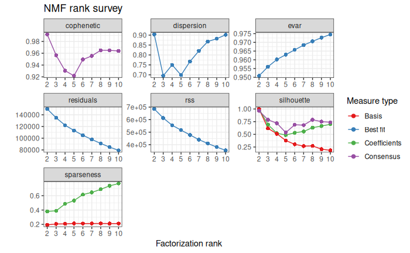

```r
nmf_data <- abs(log_norm_counts)

# Determine the optimal number of components (ranks)
estim.r <- nmf(nmf_data, 2:10, nrun = 10, seed = 123)
plot(estim.r)
```

How I Selected 8 Components

From the plot, I examined how the quality metric changed with the number of components:

[output not shown]

This approach ensures the decomposition provides interpretable and biologically meaningful results without unnecessary complexity.

[output not shown]

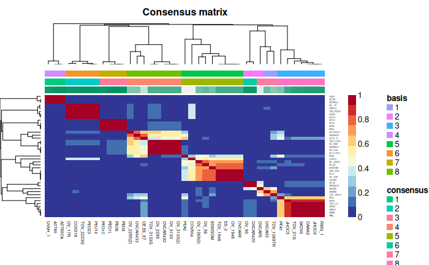

```r
consensusmap(nmf_result)
```

GO enrichment analysis helps to:

```
Identify the biological processes (BP) that are overrepresented in each cluster of genes.
Provide insights into the functional roles of the genes grouped into each component by NMF.
```

```r
perform_go_enrichment <- function(genes, component_name) {
  ego <- enrichGO(gene = genes,
                  OrgDb = org.Hs.eg.db,
                  keyType = "SYMBOL",
                  ont = "BP",
                  pAdjustMethod = "BH",
                  pvalueCutoff = 0.05,
                  qvalueCutoff = 0.2)

  return(ego)
}

# Perform GO enrichment for all components
all_enrichment_results <- list()
for (i in 1:ncol(top_10_genes)) {
  component_name <- paste("Component", i)
  enrichment_result <- perform_go_enrichment(top_10_genes[,i], component_name)
  all_enrichment_results[[component_name]] <- enrichment_result
}
```

[output not shown]